# Social_Project

tonghua.lin@rutgers.edu

4/28/2024

## R Markdown

These is a project from the course Multivariable Analysis. It’s a project about the influence of social media.

1.Explain the data collection process The data set is collected from the class. It originally contains 25 columns and around 21 rows, which is quite small. The variables include time spent in different types of apps and several outcomes, such as trouble sleep and weekly feelings.

```r
library(readr)
DataSet <- read_csv("Social Media.csv")
print(DataSet)
```

```
## # A tibble: 21 × 25
##    ID     Instagram InsTime Linkedin LinkedinTime Snapchat SnapTime Twitter
##    <chr>      <dbl> <time>     <dbl> <time>          <dbl> <time>     <dbl>
##  1 masinl         1 03:30          1 04:00               1 01:00          1
##  2 peace          1 07:44          1 05:12               1 03:41          0
##  3 Patty          1 03:46          1 07:00               1 00:32          0
##  4 Bunny          1 05:23          1 05:19               1 01:18          0
##  5 tl868          0 00:00          1 00:35               0 00:00          1
##  6 drphy          1 02:20          1 07:00               1 00:28          0
##  7 trave          1 05:22          1 04:00               0 00:00          0
##  8 19!@s          1 07:00          1 04:00               1 03:00          0
##  9 yh2020         1 08:39          1 10:00               1 03:50          0
## 10 ds2134         1 00:10          1 00:00               0 00:00          0
## # ℹ 11 more rows
## # ℹ 17 more variables: TwitterTime <time>, Whatsapp <dbl>, WhatsappTime <time>,
## #   Youtube <dbl>, YoutubeTime <time>, OTT <dbl>, OTTTime <time>, Reddit <dbl>,
## #   RedditTime <time>, ApplicationType <chr>, JobInterview <dbl>,
## #   Network <dbl>, LearningItem <dbl>, Mood <dbl>, TiredWakeUP <dbl>,
## #   TroubleSleep <dbl>, WeekFelt <dbl>
```

```r
DataSet$'Application type(Social media, OTT, Learning)'<-NULL
print(DataSet)
```

```
## # A tibble: 21 × 25
##    ID     Instagram InsTime Linkedin LinkedinTime Snapchat SnapTime Twitter
##    <chr>      <dbl> <time>     <dbl> <time>          <dbl> <time>     <dbl>
##  1 masinl         1 03:30          1 04:00               1 01:00          1
##  2 peace          1 07:44          1 05:12               1 03:41          0
##  3 Patty          1 03:46          1 07:00               1 00:32          0
##  4 Bunny          1 05:23          1 05:19               1 01:18          0
##  5 tl868          0 00:00          1 00:35               0 00:00          1
##  6 drphy          1 02:20          1 07:00               1 00:28          0
##  7 trave          1 05:22          1 04:00               0 00:00          0
##  8 19!@s          1 07:00          1 04:00               1 03:00          0
##  9 yh2020         1 08:39          1 10:00               1 03:50          0
## 10 ds2134         1 00:10          1 00:00               0 00:00          0
## # ℹ 11 more rows
## # ℹ 17 more variables: TwitterTime <time>, Whatsapp <dbl>, WhatsappTime <time>,
## #   Youtube <dbl>, YoutubeTime <time>, OTT <dbl>, OTTTime <time>, Reddit <dbl>,
## #   RedditTime <time>, ApplicationType <chr>, JobInterview <dbl>,
## #   Network <dbl>, LearningItem <dbl>, Mood <dbl>, TiredWakeUP <dbl>,
## #   TroubleSleep <dbl>, WeekFelt <dbl>
```

To clean up the data, we can exclude some Yes/No columns about the usage of different apps, since we can get the usage situation from the time spending variables. Also, we need to change time variables to numerical variables for further analysis.

```r
#drop the string column and all APP Yes/No column since time=0 means No
DataSet$Linkedin <- NULL
DataSet$Whatsapp <- NULL
DataSet$ApplicationType <- NULL
DataSet$Instagram <- NULL
DataSet$Snapchat <- NULL
DataSet$Twitter <- NULL
DataSet$Youtube <- NULL
DataSet$OTT <- NULL
DataSet$Reddit <-NULL

#change the unit of hms variables to minutes
hms_columns <- sapply(DataSet, inherits, "hms")
DataSet[hms_columns] <- lapply(DataSet[hms_columns], function(x) as.numeric(x) / 60)
print(DataSet)
```

```
## # A tibble: 21 × 16
##    ID     InsTime LinkedinTime SnapTime TwitterTime WhatsappTime YoutubeTime
##    <chr>    <dbl>        <dbl>    <dbl>       <dbl>        <dbl>       <dbl>
##  1 masinl     210          240       60         300           60         150
##  2 peace      464          312      221           0          251         255
##  3 Patty      226          420       32           0          590         111
##  4 Bunny      323          319       78           0          318         120
##  5 tl868        0           35        0          40          180         210
##  6 drphy      140          420       28           0          720         420
##  7 trave      322          240        0           0          360         180
##  8 19!@s      420          240      180           0          600         120
##  9 yh2020     519          600      230           0          369         240
## 10 ds2134      10            0        0           0           60         180
## # ℹ 11 more rows
## # ℹ 9 more variables: OTTTime <dbl>, RedditTime <dbl>, JobInterview <dbl>,
## #   Network <dbl>, LearningItem <dbl>, Mood <dbl>, TiredWakeUP <dbl>,
## #   TroubleSleep <dbl>, WeekFelt <dbl>
```

2.Exploratory Data Analysis and Visualizations Several methods can be used to do preliminary analysis and visualizations. We can check the mean and variance first.

```r
#MVA analysis after scaling, cm~0 after scaling
DataSetScaled <- scale(DataSet[-1])
S <- cov(DataSetScaled)
d <- apply(DataSetScaled, MARGIN = 1, function(x)t(x) %*% solve(S) %*% (x))
S
```

```
##                  InsTime LinkedinTime    SnapTime TwitterTime WhatsappTime
## InsTime       1.00000000  0.311623127  0.75631386 -0.20840313   0.53203043
## LinkedinTime  0.31162313  1.000000000  0.38215573 -0.12984209   0.22917702
## SnapTime      0.75631386  0.382155733  1.00000000 -0.16661385   0.38913074
## TwitterTime  -0.20840313 -0.129842093 -0.16661385  1.00000000  -0.49564743
## WhatsappTime  0.53203043  0.229177016  0.38913074 -0.49564743   1.00000000
## YoutubeTime   0.28211906  0.452859137  0.24426081 -0.18735624   0.37206744
## OTTTime       0.28968718  0.185747868  0.45648260  0.55709620   0.13380600
## RedditTime   -0.12811862 -0.009290369 -0.02909234  0.16376988  -0.13616684
## JobInterview  0.13383652  0.337869075  0.04989276 -0.20850881  -0.14722515
## Network      -0.23454196 -0.168020388 -0.27230172  0.14451484  -0.24202769
## LearningItem -0.22195605  0.542966341 -0.22092725  0.08521710  -0.16493875
## Mood          0.34397390  0.335244094  0.16313446  0.10299576   0.30877170
## TiredWakeUP  -0.16894523 -0.327910293 -0.18092050 -0.27223450  -0.04282552
## TroubleSleep  0.27547227 -0.125172555  0.36278988 -0.07841779  -0.06338177
## WeekFelt     -0.06303811  0.329615322 -0.19546427 -0.17493632   0.21907965
##              YoutubeTime       OTTTime   RedditTime JobInterview     Network
## InsTime       0.28211906  0.2896871807 -0.128118625   0.13383652 -0.23454196
## LinkedinTime  0.45285914  0.1857478679 -0.009290369   0.33786907 -0.16802039
## SnapTime      0.24426081  0.4564826024 -0.029092340   0.04989276 -0.27230172
## TwitterTime  -0.18735624  0.5570962045  0.163769879  -0.20850881  0.14451484
## WhatsappTime  0.37206744  0.1338059962 -0.136166836  -0.14722515 -0.24202769
## YoutubeTime   1.00000000  0.1610965605  0.022736032  -0.07213285  0.14147690
## OTTTime       0.16109656  1.0000000000  0.231524544  -0.08674592 -0.29670666
## RedditTime    0.02273603  0.2315245435  1.000000000  -0.11909914  0.12303678
## JobInterview -0.07213285 -0.0867459190 -0.119099141   1.00000000 -0.29864853
## Network       0.14147690 -0.2967066616  0.123036785  -0.29864853  1.00000000
## LearningItem  0.31489174 -0.1350572629 -0.284333559   0.38302648  0.19711914
## Mood         -0.00386612  0.1531657294  0.076109564   0.10122204  0.14752149
## TiredWakeUP  -0.35652915 -0.2214927665 -0.136601920   0.06401844  0.04240945
## TroubleSleep  0.03700766 -0.0006514493 -0.136601920   0.06401844  0.04240945
## WeekFelt      0.06299596 -0.1530753911 -0.175454345   0.32413563 -0.18349298
##              LearningItem        Mood TiredWakeUP  TroubleSleep    WeekFelt
## InsTime       -0.22195605  0.34397390 -0.16894523  0.2754722728 -0.06303811
## LinkedinTime   0.54296634  0.33524409 -0.32791029 -0.1251725554  0.32961532
## SnapTime      -0.22092725  0.16313446 -0.18092050  0.3627898769 -0.19546427
## TwitterTime    0.08521710  0.10299576 -0.27223450 -0.0784177942 -0.17493632
## WhatsappTime  -0.16493875  0.30877170 -0.04282552 -0.0633817690  0.21907965
## YoutubeTime    0.31489174 -0.00386612 -0.35652915  0.0370076597  0.06299596
## OTTTime       -0.13505726  0.15316573 -0.22149277 -0.0006514493 -0.15307539
## RedditTime    -0.28433356  0.07610956 -0.13660192 -0.1366019203 -0.17545434
## JobInterview   0.38302648  0.10122204  0.06401844  0.0640184400  0.32413563
## Network        0.19711914  0.14752149  0.04240945  0.0424094465 -0.18349298
## LearningItem   1.00000000  0.17200102 -0.09889364 -0.1730638618  0.26401301
## Mood           0.17200102  1.00000000  0.15811388  0.1581138830  0.45122245
## TiredWakeUP   -0.09889364  0.15811388  1.00000000  0.3571428571  0.36822985
## TroubleSleep  -0.17306386  0.15811388  0.35714286  1.0000000000  0.23014365
## WeekFelt       0.26401301  0.45122245  0.36822985  0.2301436545  1.00000000
```

```r
d
```

```
##  [1] 17.539755  9.426627 16.376155 15.918240 15.330498 17.793462 15.164135
##  [8] 11.273507 13.978187 19.047619 12.902543 14.166118  7.804700 11.189423
## [15] 18.967578 16.769265 15.208883 10.869082  8.080988 18.193558 13.999678
```

Also, there are some multi variable visualizations.

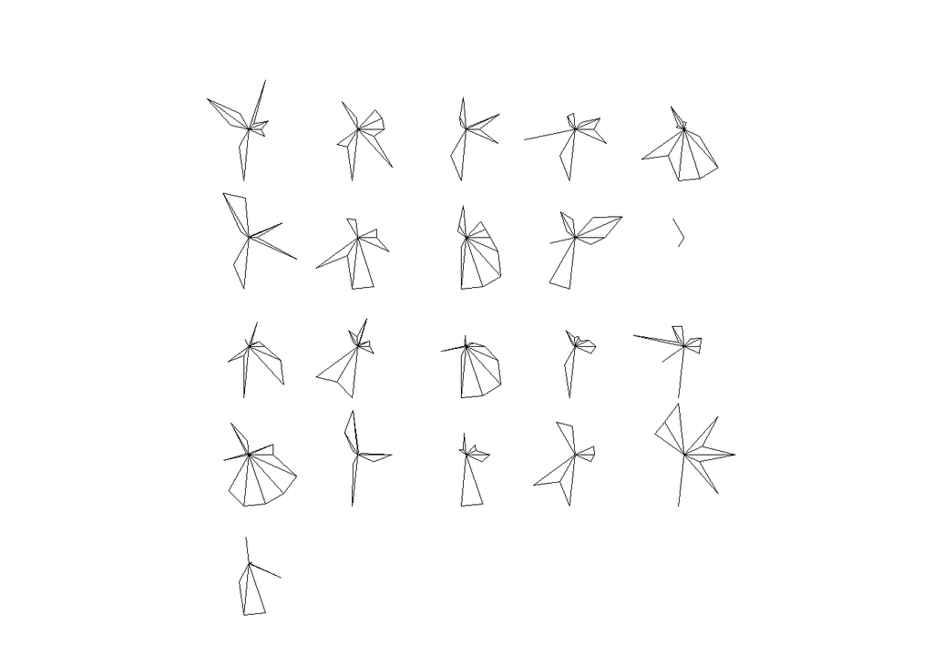

```r
#some visualization
stars(DataSetScaled)
```

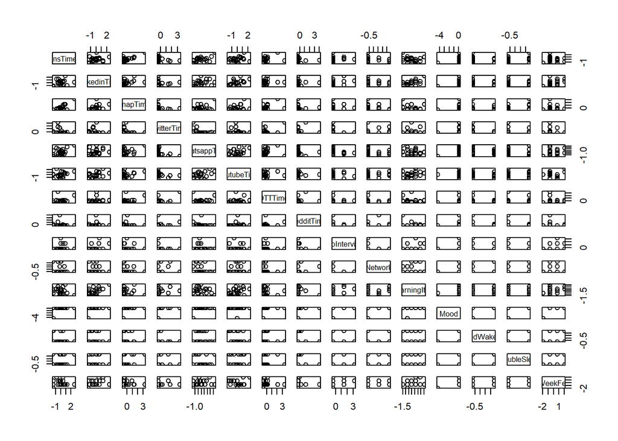

```r
pairs(DataSetScaled)
```

For further analysis the validation of variables, we can run a factor analysis.

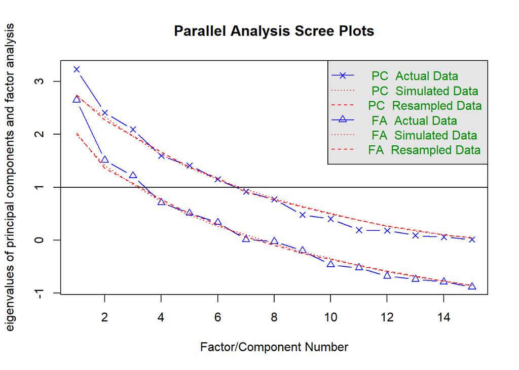

[output not shown]

```r
#Factor Analysis
library(psych)
fa.parallel(DataSetScaled)
```

```r
#We can see that 3 ~ 5 RCs are good choices.
fit <- principal(DataSetScaled,nfactors=5,rotate="varimax")
fit
```

```
## Principal Components Analysis
## Call: principal(r = DataSetScaled, nfactors = 5, rotate = "varimax")
## Standardized loadings (pattern matrix) based upon correlation matrix
##                RC1   RC3   RC4   RC2   RC5   h2   u2 com
## InsTime       0.86  0.01  0.05  0.13 -0.13 0.78 0.22 1.1
## LinkedinTime  0.37  0.81  0.05 -0.04 -0.18 0.83 0.17 1.5
## SnapTime      0.85 -0.05  0.19  0.04 -0.19 0.79 0.21 1.2
## TwitterTime  -0.33  0.03  0.87 -0.03  0.06 0.87 0.13 1.3
## WhatsappTime  0.75  0.08 -0.33  0.06  0.10 0.69 0.31 1.5
## YoutubeTime   0.48  0.51 -0.11 -0.24  0.37 0.70 0.30 3.4
## OTTTime       0.39  0.01  0.78 -0.05 -0.18 0.80 0.20 1.6
## RedditTime   -0.02 -0.11  0.44 -0.09  0.25 0.28 0.72 1.8
## JobInterview -0.09  0.41 -0.14  0.16 -0.68 0.68 0.32 1.9
## Network      -0.29  0.11  0.02  0.11  0.83 0.79 0.21 1.3
## LearningItem -0.29  0.86 -0.08 -0.02 -0.02 0.83 0.17 1.2
## Mood          0.25  0.38  0.24  0.68  0.16 0.75 0.25 2.4
## TiredWakeUP  -0.24 -0.29 -0.31  0.70 -0.06 0.74 0.26 2.1
## TroubleSleep  0.23 -0.22 -0.01  0.64 -0.01 0.51 0.49 1.5
## WeekFelt     -0.06  0.44 -0.25  0.64 -0.19 0.70 0.30 2.4
##
##                        RC1  RC3  RC4  RC2  RC5
## SS loadings           3.00 2.33 1.97 1.90 1.54
## Proportion Var        0.20 0.16 0.13 0.13 0.10
## Cumulative Var        0.20 0.36 0.49 0.61 0.72
## Proportion Explained  0.28 0.22 0.18 0.18 0.14
## Cumulative Proportion 0.28 0.50 0.68 0.86 1.00
##
## Mean item complexity =  1.8
## Test of the hypothesis that 5 components are sufficient.
##
## The root mean square of the residuals (RMSR) is  0.09
##  with the empirical chi square  36.08  with prob <  0.65
##
## Fit based upon off diagonal values = 0.87
```